# SQL to Python Pandas: A SQL User’s Quick Guide

Python

SQL

Database

Data

Unlock the essentials of translating your code from SQL to Python with this quick guide tailored for SQL users. Dive into key insights and streamline your data manipulation process.

Romina Mendez https://example.com/norajones  
2023-12-17

[figure not shown]

In this post, we will compare the implementation of Pandas and SQL for data queries. We’ll explore how to use Pandas in a manner similar to SQL by translating SQL queries into Pandas operations.

It’s important to note that there are various ways to achieve similar results, and the translation of SQL queries to Pandas will be done by employing some of its core methods.

# New York Flights ✈️ 🧳 🗽

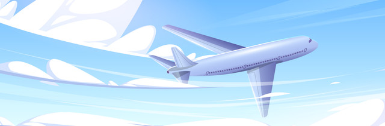

source image [Image by upklyak on Freepik](https://www.freepik.com/free-vector/plane-fly-blue-sky-with-clouds_21388594.htm#page=3&query=flights%20illustration&position=19&from_view=search&track=ais&uuid=82650d86-0491-4a8c-8ac1-763986dbdfb7%22)

We aim to explore the diverse Python Pandas methods, focusing on their application through the **nycflights13** datasets. This datasets offer comprehensive information about `airlines`, `airports`, `weather conditions`, and `aircraft` for all `flights` passing through New York airports in 2013.

Through this exercise, we’ll not only explore Pandas functionality but also learn to apply fundamental SQL concepts in a Python data manipulation environment.

## Entity-relationship diagram [DER]

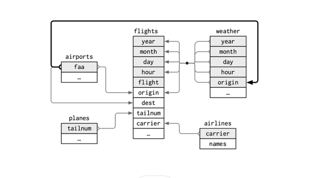

## Installation: Setting Up nycflights13

To install the nycflights13 library, you can use the following command:

```bash
!pip install nycflights13
```

# 🟢 Pandas, NumPy, and nycflights13 for Data Analysis in Python

```python
import pandas as pd
import numpy as np
import nycflights13 as nyc
```

In the following lines of code, we are assigning two specific datasets from the nycflights13 library to variables.

```python
flights = nyc.flights
airlines = nyc.airlines
```

# 🟢 SELECT and FROM Statements

### 📗 SELECT: All Columns

The following SQL query retrieves all columns and rows from the “🛩️ flights” table. In Pandas, the equivalent is simply writing the DataFrame name, in this case, “flights.” For example:

🔍`sql`

```sql
  SELECT * FROM flights;
```

🐍`python`

```python
flights
```

### 📗 SELECT: Specific Columns

To select specific columns from a Pandas DataFrame, you can use the following syntax:

🔍`sql`

```sql
  select
    year,
    month,
    day,
    dep_time,
    flight,
    tailnum,
    origin,
    dest
  from flights;
```

🐍`python`

```python
(
    flights
        .filter(['year', 'month', 'day', 'dep_time', 'flight',
                'tailnum', 'origin', 'dest'])
)
```

# 🟢 Filtering Operators (WHERE)

### 📗 Utilizing ‘WHERE’ for Equality ( = )

To filter all ✈️ flights where the origin is ‘JFK’ in Pandas, you can use the following code:

🔍`sql`

```sql
select year, month , day, dep_time, flight, tailnum, origin, dest
from flights
  where origin = 'JFK'
limit 10;
```

🐍`python`

```python
(   flights
      .filter(['year', 'month', 'day', 'dep_time', 'flight',
              'tailnum', 'origin', 'dest'])
      .query("origin=='JFK'")
      .head(10)
)
```

To achieve the same filtering in Pandas for specific criteria: * ✈️ Flights departing from JFK, LGA, or EWR.

🔍`sql`

```sql
select year, month , day, dep_time, flight, tailnum, origin, dest
from flights
  where origin in ( 'JFK', 'LGA', 'EWR' )
limit 10;
```

🐍`python`

```python
 (  flights
        .filter(['year', 'month', 'day', 'dep_time', 'flight',
        'tailnum', 'origin', 'dest'])
      .query("origin in ['JFK', 'EWR', 'LGA']")
      .head(10)
)
```

### 📗 Utilizing ‘WHERE’ with Inequality ( != )

To achieve the same filtering in Pandas for specific criteria:

- ✈️ Flights departing from JFK, LGA, or EWR.
- ✈️ Flights not destined for Miami (MIA).

🔍`sql`

```sql
select year, month , day, dep_time, flight, tailnum, origin, dest
from flights
  where origin in ( 'JFK', 'LGA', 'EWR' ) and dest<>'MIA'
limit 10;
```

🐍`python`

```python
(   flights
      .filter(['year', 'month', 'day', 'dep_time', 'flight',
              'tailnum', 'origin', 'dest'])
      .query("(origin in ['JFK', 'EWR', 'LGA']) and (dest != 'MIA')")
   .head(10)
)
```

### 📗 Utilizing ‘WHERE’ for Comparisons (>=, <=, <, >)

To achieve the same filtering in Pandas for specific criteria:

- ✈️ Flights departing from JFK, LGA, or EWR.
- ✈️ Flights not destined for Miami (MIA).
- ✈️ Flights with a distance less than or equal to 1000 km.

🔍`sql`

```sql
select year, month , day, dep_time, flight, tailnum, origin, dest
from flights
  where origin in ( 'JFK', 'LGA', 'EWR' )
   and dest<>'MIA'
   and distance < = 1000
limit 10;
```

🐍`python`

```python
( flights
      .filter(['year', 'month', 'day', 'dep_time', 'flight',
            'tailnum', 'origin', 'dest', 'time_hour', 'distance'])
      .query("(origin in ['JFK', 'EWR', 'LGA']) and (dest != 'MIA') and (distance <= 1000)")
      .head(10)
)
```

### 📗 Utilizing ‘WHERE’ with between operator

To achieve the same filtering in Pandas for specific criteria:

- ✈️ Flights departing from JFK, LGA, or EWR.
- ✈️ Flights not destined for Miami (MIA).
- ✈️ Flights with a distance less than or equal to 1000 km.
- ✈️ Flights within the period from September 1, 2013, to September 30, 2013.

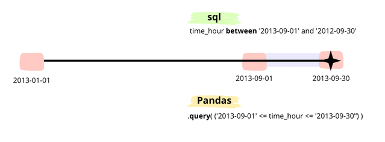

🔍`sql`

```sql
select year, month , day, dep_time, flight, tailnum, origin, dest
from flights
  where origin in ( 'JFK', 'LGA', 'EWR' )
   and dest<>'MIA'
   and distance < = 1000
   and time_hour between '2013-09-01' and '2012-09-30'
limit 10;
```

🐍`python`

```python
(   flights.filter([['year', 'month', 'day', 'dep_time', 'flight',
          'tailnum', 'origin', 'dest', 'time_hour', 'distance'])
      .query(
            "(origin in ['JFK', 'EWR', 'LGA'])"
             " and (dest != 'MIA')"
             " and (distance <= 1000)"
             " and ('2013-09-01' <= time_hour <= '2013-09-30')"
         )
      .head(10)
)
```

### 📗 Utilizing ‘WHERE’ with “LIKE” Clause

To achieve the same filtering in Pandas for specific criteria:

- ✈️ Flights departing from JFK, LGA, or EWR.
- ✈️ Flights not destined for Miami (MIA).
- ✈️ Flights with a distance less than or equal to 1000 km.
- ✈️ Flights within the period from September 1, 2013, to September 30, 2013.
- ✈️ Flights where the tailnum contains ‘N5’ in the text.

You can use the following code:

🔍`sql`

```sql
select year, month , day, dep_time, flight, tailnum, origin, dest
from flights
  where origin in ( 'JFK', 'LGA', 'EWR' )
   and dest<>'MIA'
   and distance < = 1000
   and time_hour between '2013-09-01' and '2012-09-30'
   and tailnum like '%N5%'
limit 10;
```

🐍`python`

```python
(
    flights
      .filter(['year', 'month', 'day', 'dep_time', 'flight', 'tailnum',
        'origin', 'dest', 'time_hour'])
      .query(
             " (origin in ['JFK', 'EWR', 'LGA'])"
             " and (dest != 'MIA') "
             " and ('2013-09-01' <= time_hour <= '2013-09-30')"
             " and (tailnum.str.find('N5')>=0)"
       )
      .head(10)
)
```

### 📗 Utilizing ‘WHERE’ with Null or Not Null Values

To achieve the same filtering in Pandas for specific criteria:

- ✈️ Flights departing from JFK, LGA, or EWR.
- ✈️ Flights not destined for Miami (MIA).
- ✈️ Flights with a distance less than or equal to 1000 km.
- ✈️ Flights within the period from September 1, 2013, to September 30, 2013.
- ✈️ Flights where the tailnum contains ‘N5’ in the text.
- ✈️ Flights where dep_time is null

You can use the following code:

🔍`sql`

```sql
select year, month , day, dep_time, flight, tailnum, origin, dest
from flights
  where origin in ( 'JFK', 'LGA', 'EWR' )
   and dest<>'MIA'
   and distance < = 1000
   and time_hour between '2013-09-01' and '2012-09-30'
   and tailnum like '%N5%'
   and dep_time is null
limit 10;
```

🐍`python`

```python
(
    flights
      .filter(['year', 'month', 'day', 'dep_time', 'flight',
              'tailnum', 'origin', 'dest', 'time_hour'])
      .query(
             " (origin in ['JFK', 'EWR', 'LGA'])"
             " and (dest != 'MIA') "
             " and ('2013-09-01' <= time_hour <= '2013-09-30')"
             " and (tailnum.str.find('N5')>=0)"
             " and dep_time.isnull()"
       )
      .head(10)
)
```

# 🟢 Order by Statement

The **.sort_values()** methods in Pandas are equivalent to the ORDER BY clause in SQL.

1️⃣.`**.sort_values(['origin','dest'], ascending=False)**`: This method sorts the DataFrame based on the ‘origin’ and ‘dest’ columns in descending order (from highest to lowest). In SQL, this would be similar to the **`ORDER BY origin DESC, dest DESC`** clause.

2️⃣.`**.sort_values(['day'], ascending=True)**`: This method sorts the DataFrame based on the ‘day’ column in ascending order (lowest to highest). In SQL, this would be similar to the **`ORDER BY day ASC`** clause.

Both methods allow you to sort your DataFrame according to one or more columns, specifying the sorting direction with the ascending parameter. True means ascending order, and False means descending order.

🔍`sql`

```sql
select year, month , day, dep_time, flight, tailnum, origin, dest
from flights
  where origin in ( 'JFK', 'LGA', 'EWR' )
   and dest<>'MIA'
   and distance < = 1000
   and time_hour between '2013-09-01' and '2012-09-30'
   and tailnum like '%N5%'
   and dep_time is null
order by  origin, dest desc
limit 10;
```

🐍`python`

```python
(
    flights
      .filter(['year', 'month', 'day', 'dep_time', 'flight',
              'tailnum', 'origin', 'dest', 'time_hour'])
      .query(
             " (origin in ['JFK', 'EWR', 'LGA'])"
             " and (dest != 'MIA') "
             " and ('2013-09-01' <= time_hour <= '2013-09-30')"
             " and (tailnum.str.find('N5')>=0)"
             " and year.notnull()"
       )
      .sort_values(['origin','dest'],ascending=False)
      .head(10)

)
```

# 🟢 Distinct Values: Removing Duplicates from Results

To perform a distinct select in pandas, you need to first execute the entire query, and then apply the `drop_duplicates()` method to eliminate all duplicate rows.

🔍`sql`

```sql
select distinct origin, dest
from flights
  where origin in ( 'JFK', 'LGA', 'EWR' )
   and dest<>'MIA'
   and time_hour between '2013-09-01' and '2012-09-30'
order by  origin, dest desc;
```

🐍`python`

```python
(
    flights
      .filter(['origin','dest','time_hour'])
      .query(
             " (origin in ['JFK', 'EWR', 'LGA'])"
             " and (dest != 'MIA') "
             " and ('2013-09-01' <= time_hour <= '2013-09-30')"
       )
      .filter(['origin','dest'])
      .drop_duplicates()

)
```

# 🟢 Adding Calculated Columns

Now, let’s introduce a new calculated column called “delay_total,” where we sum the values from the “dep_delay” and “arr_delay” columns.

🔍`sql`

```sql
select
  origin,
  dest,
  time_hour,
  dep_delay,
  arr_delay,
  flights.dep_delay + flights.arr_delay as delay_total
from flights
  where origin in ( 'JFK', 'LGA', 'EWR' )
   and dest<>'MIA'
   and time_hour between '2013-09-01' and '2012-09-30';
```

🐍`python`

```python
(
    flights
      .filter(['origin', 'dest', 'time_hour', 'dep_delay', 'arr_delay'])
      .assign(delay_total = flights.dep_delay + flights.arr_delay )
      .query(
             " (origin in ['JFK', 'EWR', 'LGA'])"
             " and (dest != 'MIA') "
             " and ('2013-09-01' <= time_hour <= '2013-09-30')"
       )
)
```

# 🟢 Group by Statement

To perform a **GROUP BY** operation in pandas, we’ll use the groupby method, which operates similarly to its SQL counterpart. Similarly, we can employ common aggregate functions such as sum, max, min, mean (equivalent to avg in SQL), and count. Below is a simple example to illustrate this process:

🔍`sql`

```sql
select
  year,
  month,
  max(dep_delay) as dep_delay,
from flights
group by
  year,
  month;
```

🐍`python`

```python
(
    flights
      .groupby(['year','month'],as_index=False)
      ['dep_delay'].max()
)
```

# 🟢 Group by and Having Statement

In the following example, we’ll explore how to implement a **HAVING** clause in pandas, leveraging the query method, as we’ve done previously for filtering.

🔍`sql`

```sql
select
  year,
  month,
  max(dep_delay) as dep_delay,
from flights
group by
  year,
  month
having max(dep_delay)>1000
```

🐍`python`

```python
(
    flights
      .groupby(['year','month'],as_index=False)['dep_delay']
      .max()
      .query('(dep_delay>1000)') # having
)
```

# 🟢 Group by with multiple calculations

When working with pandas and needing to perform multiple calculations on the same column or across different columns, the agg function becomes a valuable tool. It allows you to specify a list of calculations to be applied, providing flexibility and efficiency in data analysis.

Consider the following SQL query:

🔍`sql`

```sql
select
  year,
  month,
  max(dep_delay)  as dep_delay_max,
  min(dep_delay)  as dep_delay_min,
  mean(dep_delay) as dep_delay_mean,
  count(*)        as dep_delay_count,
  max(arr_delay)  as arr_delay_max,
  min(arr_delay)  as arr_delay_min,
  sum(arr_delay)  as arr_delay_sum
from flights
group by
  year,
  month
```

🐍`python`

```python
result = (
    flights
      .groupby(['year','month'],as_index=False)
      .agg({'dep_delay':['max','min','mean','count'], 'arr_delay':['max','min','sum']})
)

# Concatenate function names with column names
result.columns = result.columns.map('_'.join)

# Print the results
result
```

# 🟢 Union Statement

To execute a UNION ALL operation in Pandas, it is necessary to create two DataFrames and concatenate them using the concat method. Unlike SQL, a DataFrame in Pandas can be combined to generate additional columns or additional rows. Therefore, it is essential to define how the concatenation should be performed:

- **axis=1** => Union that appends another dataset to the right, generating more columns.
- **axis=0** => Union that appends more rows.

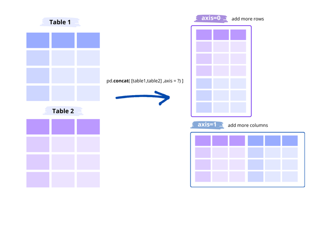

In our example, we will perform the equivalent of a UNION ALL in SQL, so we will use axis=0.

🔍`sql`

```sql
select
  origin,
  dest,
  time_hour,
  dep_delay,
  arr_delay,
  flights.dep_delay + flights.arr_delay as delay_total ,
  'NYC' group
FROM flights
  WHERE origin in ( 'JFK', 'LGA', 'EWR' )
   and dest<>'MIA'
   and time_hour between '2013-09-01' and '2012-09-30'
ORDER BY flights.dep_delay + flights.arr_delay DESC
LIMIT 3
UNION ALL
select
  origin,
  dest,
  time_hour,
  dep_delay,
  arr_delay,
  flights.dep_delay + flights.arr_delay as delay_total ,
  'MIA' group
FROM flights
  WHERE origin in ( 'JFK', 'LGA', 'EWR' )
   and time_hour between '2013-07-01' and '2012-09-30'
  ORDER BY flights.dep_delay + flights.arr_delay DESC
  LIMIT 2;
```

🐍`python`

```python
Flights_NYC = (
    flights
      .filter(['year', 'month', 'day', 'dep_time', 'flight',
              'tailnum', 'origin', 'dest', 'time_hour',
              'dep_delay', 'arr_delay'])
      .assign(delay_total = flights.dep_delay + flights.arr_delay )
      .query(
             " (origin in ['JFK', 'EWR', 'LGA'])"
             " and ('2013-09-01' <= time_hour <= '2013-09-30')"
       )
     .assign(group ='NYC')
     .sort_values('delay_total',ascending=False)
     .head(3)
)

Flights_MIAMI = (
    flights
      .filter(['year', 'month', 'day', 'dep_time', 'flight',
              'tailnum', 'origin', 'dest', 'time_hour',
              'dep_delay', 'arr_delay'])
      .assign(delay_total = flights.dep_delay + flights.arr_delay )
      .query(
             " (dest in ['MIA', 'OPF', 'FLL'])"
             " and ('2013-07-01' <= time_hour <= '2013-09-30')"
       )
     .assign(group ='MIA')
     .sort_values('delay_total',ascending=False)
     .head(2)
)

# union all
pd.concat([ Flights_NYC,Flights_MIAMI],axis=0)
```

# 🟢 CASE WHEN Statement

To replicate the `CASE WHEN` statement, we can use two different methods from NumPy:

1️⃣. If there are only two conditions, for example, checking if the total delay exceeds 0, then we label it as “Delayed”; otherwise, we label it as “On Time”. For this, the `np.where` method from NumPy is utilized.

🔍`sql`

```sql
select
  origin,
  dest,
  time_hour,
  dep_delay,
  arr_delay,
  (case
    when flights.dep_delay + flights.arr_delay >0 then 'Delayed'
    else 'On Time' end) as status ,
FROM flights
LIMIT 5;
```

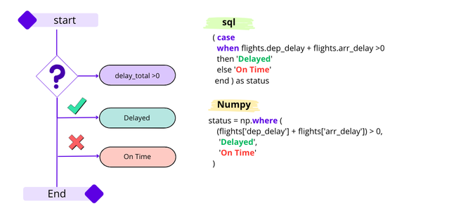

🐍`python`

```python
(
    flights
      .filter(['year', 'month', 'day', 'dep_time',
              'flight', 'tailnum', 'origin', 'dest',
              'time_hour', 'dep_delay', 'arr_delay'])
      .assign(status=np.where((flights['dep_delay'] + flights['arr_delay']) > 0,                                'Delayed',
                               'On Time'))
      .head(5)
)
```

2️⃣. In case there are more conditions, such as identifying Miami airports and labeling them as “MIA”, labeling “ATL” airports that they are in Altanta, and for any other cases, using the label “OTHER”. For this, the `np.select` method from NumPy is employed.

| City | Name | Acronym |
| --- | --- | --- |
| Miami | Miami International | (MIA) |
| Miami | Opa-locka Executive | (OPF) |
| Miami | Fort Lauderdale-Hollywood | (FLL) |
| Atlanta | Hartsfield-Jackson Atlanta | (ATL) |
| Atlanta | DeKalb-Peachtree | (PDK) |
| Atlanta | Fulton County | (FTY) |

🔍`sql`

```sql
select
  origin,
  dest,
  time_hour,
  dep_delay,
  arr_delay,
  (case
    when dest in ('ATL','PDK','FTY') then 'ATL'
    when dest in ('MIA','OPF','FLL') then 'MIA'
    else 'Other'
  end) as city ,
FROM flights
LIMIT 10;
```

🐍`python`

```python
(
    flights
      .filter(['year', 'month', 'day', 'dep_time', 'flight',
              'tailnum', 'origin', 'dest', 'time_hour',
              'dep_delay', 'arr_delay'])
      .assign( city=np.select([flights['dest'].isin(['ATL','PDK','FTY']),
                             flights['dest'].isin(['MIA', 'OPF', 'FLL'])],
                             ['ATL','MIA'],
                             default='Other')
              )
    .head(10)
)
```

# 🟢 JOIN Statement

Entity relationship diagram [DER]

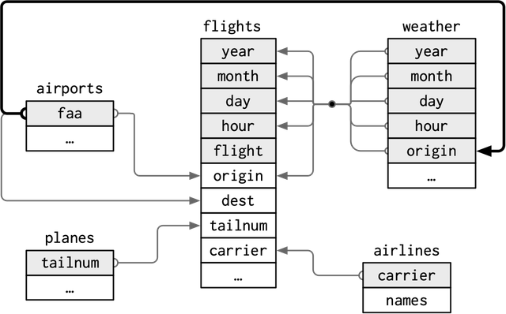

When performing a join in Pandas, the merge method should be used.

## 📗 Join Types

How: Specifies the type of join to be performed. Available options: `{'left', 'right', 'outer', 'inner', 'cross'}`

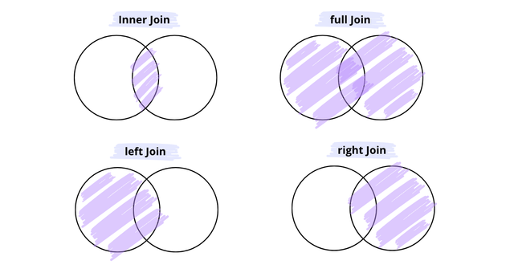

joins

## 📗 Join Key

On: The key on which the tables will be joined. If more than one column is involved, a list should be provided. Examples:

- Single variable: `on='year'`

```python
fligths.merge(planes, how='inner', on='tailnum')
```

- Two variables: on=[‘year’,‘month’,‘day’]

```python
fligths.merge(weather, how='inner', on=['year','month','day'])
```

- left_on/right_on: When the columns have different names, these parameters should be used. For example:

```python
fligths.merge(airports, how='inner', left_on = 'origin', rigth_on='faa')
```

Here’s an example using the airlines and flights tables:

🔍`sql`

```sql
select
  f.year,
  f.month,
  f.day,
  f.dep_time,
  f.flight,
  f.tailnum,
  f.origin as airport_origen,
  f.dest,
  f.time_hour,
  f.dep_delay,
  f.arr_delay,
  f.carrier,
  a.name as airline_name
FROM flights  f
  left join airlines a on f.carrier = a.carrier
LIMIT 5;
```

# 🟢 Rename

> The rename method is used to rename columns, similar to the “as” clause in SQL.

🐍`python`

```python
(
    flights
      .filter(['year', 'month', 'day', 'dep_time', 'flight',
        'tailnum', 'origin', 'dest', 'time_hour', 'dep_delay',
        'arr_delay', 'carrier'])
      .merge(airlines, how = 'left', on ='carrier')
      .rename(columns= {'name':'airline_name', 'origin':'airport_origen'})
      .head(5)
)
```

> You can find all the code in a 🐍 python notebook in the following [[link](https://gist.github.com/r0mymendez/741cd2311eb4d4b321d187642b3d5060)]

# 📚 References

If you want to learn more about `Pandas` and `NumPy`…

- [[Pandas](https://pandas.pydata.org/)]

- [[NumPy](https://numpy.org/)]

Other references:

- Image preview reference: [Imagen de vectorjuice en Freepik]